# Exploring Red Wine Quality by Jin Lim

### Plot Three

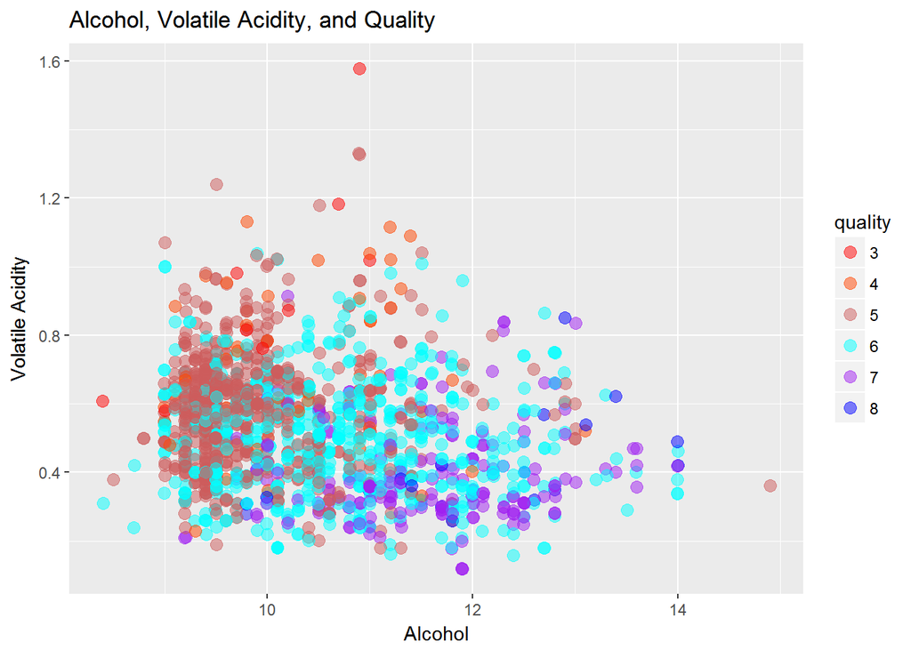

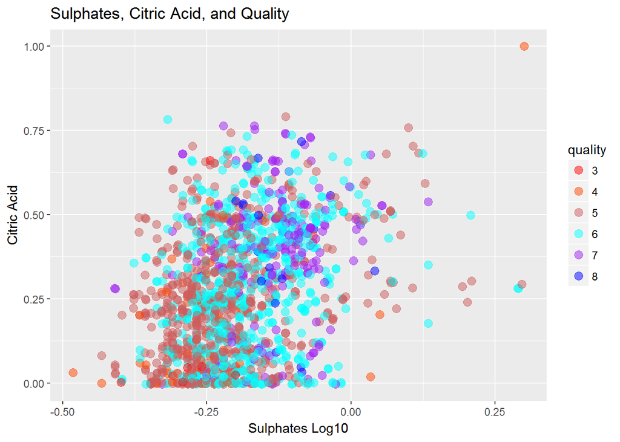

### Description Three

> And so, putting all four factors (Alcohol, Volatile Acidity, Sulphates and Citric Acid together) together. The best-rated wines tend to have a high alcohol content and low volatile acidity. They also tend to have more citric acid and sulphates.

# Reflection

> The Red Wine dataset concerns the red variant of the Portuguese “Vinho Verde” wine. It contains 1599 observations and 11 input variables, as well as an output variable called “quality” on a scale of 0 (very bad)-10 (very excellent). There is no single fully-robust explanatory relationship between these variables and quality; rather, the inputs all work together to guide wine rating. The four variables with the most driving force are alcohol (0.476), volatile acidity (-0.391), sulphates (0.251) and citric acid (0.226). These variables were the main point of focus in most of this project’s visualizations.

> Observations and reflections on variables:  
> 1. **Alcohol:** Alcohol is the most correlated factor with wine quality. The higher the alcohol rating, the better the tasters rated the wine. Perhaps the alcohol content itself imparts a sharper and stronger taste. More likely, alcohol content is a result of fermentation length; the longer the fermentation, the more alcohol extracted, and the greater the perception of “quality” and perhaps subtle tastes imparted by aging.  
> 2. **Volatile Acidity:** Or acetic acid. The more acetic acid, the lower the wine is rated. Obviously, a vinegar-like taste cannot be good for ratings.  
> 3. **Sulphates:** These are added to wines in order to combat bacterial growth and prevent spoilage. It would make sense that wines with the least spoilage taste the best.  
> 4. **Citric Acid:** Another additive to wines. The large number of “0” citric acid entries in this dataframe suggests that it is also a personal decision by the winemaker himself. Adding this can impart a “fresh” feel to the wine’s taste, though again, this is at the winemaker’s discretion; not all good wines require that “zing”.

> I was very surprised that residual sugar had almost zero correlation with wine rating. Perhaps that is the point: I am not a wine-drinker, and I tend to enjoy sweeter drinks. Obviously, one’s palate must be broadened in order to truly appreciate the subtleties of such a high-class beverage.

> Wine-tasting is a complex subject, and is itself subject to human biases. In that vein, perhaps it would have served the data well to include qualitative or categorical variables to the list, instead of purely numerical ones. Things like the color and hue of the wine might have contributed to rating as well. At the end of the day, the linear model I constructed was too simple to adequately explain wine rating. Wine is no doubt more than the sum of its parts, and certainly more than a few chemical components.